# Lab 07

Graham Irons

2/18/2022

#### Step 1: Set Global Options and Load Packages

#### Step 2: Import Water Use Data; Clean Data

The data for this lab are available from the [United States Geological Survey](https://water.usgs.gov/watuse/data/) for years 1950-2015.

Table 1: “Sets” of data, for which each of the sets have ALL column tags in common. Data from USGS (1950-2015). Bold indicate major differences between report years.

| year | public supply | irrigation | rural | industrial | thermo | state |
| --- | --- | --- | --- | --- | --- | --- |
| 1950-1955 | ps_wgw_fr + ps_wsw_fr | ir_wgw_fr + ir_wsw_fr | **NA** | **inpt_wgw_fr + inpt_wsw_fr** | **NA** | **area** |
| 1960-1980 | ps_wgw_fr + ps_wsw_fr | ir_wgw_fr + ir_wsw_fr | do_wgw_fr + do_wsw_fr + ls_wgw_fr + ls_wsw_fr | **oi_wgw_fr + oi_wsw_fr** | pt_wgw_fr + pt_wsw_fr | **area** |
| **1985-1990** | ps_wgwfr + ps_wswfr | ir_wgwfr + ir_wswfr | **do_ssgwf + do_ssswf + ls_gwtot + ls_swtot** | in_wgwfr + in_wswfr + mi_wgwfr + mi_wswfr | pt_wgwfr + pt_wswfr | **scode** |
| 1995 | ps_wgw_fr + ps_wsw_fr | ir_wgw_fr + ir_wsw_fr | do_wgw_fr + do_wsw_fr + ls_wgw_fr + ls_wsw_fr | in_wgw_fr + in_wsw_fr + mi_wgw_fr + mi_wsw_fr | pt_wgw_fr + pt_wsw_fr | **state_code** |
| 2000 | ps_wgw_fr + ps_wsw_fr | **it_wgw_fr + it_wsw_fr** | do_wgw_fr + do_wsw_fr + ls_wgw_fr + ls_wsw_fr | in_wgw_fr + in_wsw_fr + mi_wgw_fr + mi_wsw_fr | pt_wgw_fr + pt_wsw_fr | statefips |
| 2005 | ps_wgw_fr + ps_wsw_fr | ir_wgw_fr + ir_wsw_fr | do_wgw_fr + do_wsw_fr + ls_wgw_fr + ls_wsw_fr | in_wgw_fr + in_wsw_fr + mi_wgw_fr + mi_wsw_fr | pt_wgw_fr + pt_wsw_fr | statefips |
| 2010-2015 | ps_wgw_fr + ps_wsw_fr | ir_wgw_fr + ir_wsw_fr | do_wgw_fr + do_wsw_fr + **li_wgw_fr + li_wsw_fr** | in_wgw_fr + in_wsw_fr + mi_wgw_fr + mi_wsw_fr | pt_wgw_fr + pt_wsw_fr | statefips |

#### Step 3: Organize data by Sector

```r
#object for d_year that creates sectors using highlighted data from Table 1
wu_1950 <- d_1950 %>%
              mutate("State" = area,
                     "Public Supply" = ps_wgw_fr + ps_wsw_fr,
                     "Irrigation" = ir_wgw_fr + ir_wsw_fr,
                     "Rural" = NA,
                     "Industrial" = inpt_wgw_fr + inpt_wsw_fr,
                     "Thermoelectric" = NA,
                     "Year" = 1950) %>%
              select(State, "Public Supply", Irrigation, Rural, Industrial, Thermoelectric, Year) %>%
              pivot_longer(cols = 2:6,
                           names_to = "Sector",
                           values_to = "Withdrawals")

wu_1955 <- d_1955 %>%
              mutate("State" = area,
                     "Public Supply" = ps_wgw_fr + ps_wsw_fr,
                     "Irrigation" = ir_wgw_fr + ir_wsw_fr,
                     "Rural" = NA,
                     "Industrial" = inpt_wgw_fr + inpt_wsw_fr,
                     "Thermoelectric" = NA,
                     "Year" = 1955) %>%
              select(State, "Public Supply", Irrigation, Rural, Industrial, Thermoelectric, Year)%>%
              pivot_longer(cols = 2:6,
                           names_to = "Sector",
                           values_to = "Withdrawals")

wu_1960 <- d_1960 %>%
              mutate("State" = area,
                     "Public Supply" = ps_wgw_fr + ps_wsw_fr,
                     "Irrigation" = ir_w_fr_to,                                 #ir_w_fr_to is used bc lack of data for fr and sw
                     "Rural" = do_wgw_fr + do_wsw_fr + ls_wgw_fr + ls_wsw_fr,
                     "Industrial" = oi_wgw_fr + oi_wsw_fr,
                     "Thermoelectric" = pt_wgw_fr + pt_wsw_fr,
                     "Year" = 1960) %>%
              select(State, "Public Supply", Irrigation, Rural, Industrial, Thermoelectric, Year)%>%
              pivot_longer(cols = 2:6,
                           names_to = "Sector",
                           values_to = "Withdrawals")

wu_1965 <- d_1965 %>%
              mutate("State" = area,
                     "Public Supply" = ps_wgw_fr + ps_wsw_fr,
                     "Irrigation" = ir_wgw_fr + ir_wsw_fr,
                     "Rural" = do_wgw_fr + do_wsw_fr + ls_wgw_fr + ls_wsw_fr,
                     "Industrial" = oi_wgw_fr + oi_wsw_fr,
                     "Thermoelectric" = pt_wgw_fr + pt_wsw_fr,
                     "Year" = 1965) %>%
              select(State, "Public Supply", Irrigation, Rural, Industrial, Thermoelectric, Year)%>%
              pivot_longer(cols = 2:6,
                           names_to = "Sector",
                           values_to = "Withdrawals")

wu_1970 <- d_1970 %>%
              mutate("State" = area,
                     "Public Supply" = ps_wgw_fr + ps_wsw_fr,
                     "Irrigation" = ir_wgw_fr + ir_wsw_fr,
                     "Rural" = do_wgw_fr + do_wsw_fr + ls_wgw_fr + ls_wsw_fr,
                     "Industrial" = oi_wgw_fr + oi_wsw_fr,
                     "Thermoelectric" = pt_wgw_fr + pt_wsw_fr,
                     "Year" = 1970) %>%
              select(State, "Public Supply", Irrigation, Rural, Industrial, Thermoelectric, Year)%>%
              pivot_longer(cols = 2:6,
                           names_to = "Sector",
                           values_to = "Withdrawals")

wu_1975 <- d_1975 %>%
              mutate("State" = area,
                     "Public Supply" = ps_wgw_fr + ps_wsw_fr,
                     "Irrigation" = ir_wgw_fr + ir_wsw_fr,
                     "Rural" = do_wgw_fr + do_wsw_fr + ls_wgw_fr + ls_wsw_fr,
                     "Industrial" = oi_wgw_fr + oi_wsw_fr,
                     "Thermoelectric" = pt_wgw_fr + pt_wsw_fr,
                     "Year" = 1975) %>%
              select(State, "Public Supply", Irrigation, Rural, Industrial, Thermoelectric, Year)%>%
              pivot_longer(cols = 2:6,
                           names_to = "Sector",
                           values_to = "Withdrawals")

wu_1980 <- d_1980 %>%
              mutate("State" = area,
                     "Public Supply" = ps_wgw_fr + ps_wsw_fr,
                     "Irrigation" = ir_wgw_fr + ir_wsw_fr,
                     "Rural" = do_wgw_fr + do_wsw_fr + ls_wgw_fr + ls_wsw_fr,
                     "Industrial" = oi_wgw_fr + oi_wsw_fr,
                     "Thermoelectric" = pt_wgw_fr + pt_wsw_fr,
                     "Year" = 1980) %>%
              select(State, "Public Supply", Irrigation, Rural, Industrial, Thermoelectric, Year)%>%
              pivot_longer(cols = 2:6,
                           names_to = "Sector",
                           values_to = "Withdrawals")

wu_1985 <- d_1985 %>%
              mutate("State" = scode,
                     "Public Supply" = ps_wgwfr + ps_wswfr,
                     "Irrigation" = ir_wgwfr + ir_wswfr,
                     "Rural" = do_ssgwf + do_ssswf + ls_gwtot + ls_swtot,
                     "Industrial" = in_wgwfr + in_wswfr + mi_wgwfr + mi_wswfr,
                     "Thermoelectric" = pt_wgwfr + pt_wswfr ,
                     "Year" = 1985) %>%
              select(State, "Public Supply", Irrigation, Rural, Industrial, Thermoelectric, Year) %>%
              group_by(State, Year) %>%
              summarize(across(1:5, sum))%>%
              pivot_longer(cols = 3:7,
                           names_to = "Sector",
                           values_to = "Withdrawals")

wu_1990 <- d_1990 %>%
              mutate("State" = scode,
                     "Public Supply" = ps_wgwfr + ps_wswfr,
                     "Irrigation" = ir_wgwfr + ir_wswfr,
                     "Rural" = do_ssgwf + do_ssswf + ls_gwtot + ls_swtot,
                     "Industrial" = in_wgwfr + in_wswfr + mi_wgwfr + mi_wswfr,
                     "Thermoelectric" = pt_wgwfr + pt_wswfr ,
                     "Year" = 1990) %>%
              select(State, "Public Supply", Irrigation, Rural, Industrial, Thermoelectric, Year) %>%
              group_by(State, Year) %>%
              summarize(across(1:5, sum))%>%
              pivot_longer(cols = 3:7,
                           names_to = "Sector",
                           values_to = "Withdrawals")

wu_1995 <- d_1995 %>%
              mutate("State" = state_code,
                     "Public Supply" = ps_wgw_fr + ps_wsw_fr,
                     "Irrigation" = ir_wgw_fr + ir_wsw_fr,
                     "Rural" = do_wgw_fr + do_wsw_fr + ls_wgw_fr + ls_wsw_fr    ,
                     "Industrial" = in_wgw_fr + in_wsw_fr + mi_wgw_fr + mi_wsw_fr,
                     "Thermoelectric" = pt_wgw_fr + pt_wsw_fr   ,
                     "Year" = 1995) %>%
              select(State, "Public Supply", Irrigation, Rural, Industrial, Thermoelectric, Year) %>%
              group_by(State, Year) %>%
              summarize(across(1:5, sum))%>%
              pivot_longer(cols = 3:7,
                           names_to = "Sector",
                           values_to = "Withdrawals")

wu_2000 <- d_2000 %>%
              mutate("State" = statefips,
                     "Public Supply" = ps_wgw_fr + ps_wsw_fr,
                     "Irrigation" = it_wgw_fr + it_wsw_fr   ,
                     "Rural" = do_wgw_fr + do_wsw_fr + ls_wgw_fr + ls_wsw_fr    ,
                     "Industrial" = in_wgw_fr + in_wsw_fr + mi_wgw_fr + mi_wsw_fr,
                     "Thermoelectric" = pt_wgw_fr + pt_wsw_fr   ,
                     "Year" = 2000) %>%
              select(State, "Public Supply", Irrigation, Rural, Industrial, Thermoelectric, Year) %>%
              group_by(State, Year) %>%
              summarize(across(1:5, sum))%>%
              pivot_longer(cols = 3:7,
                           names_to = "Sector",
                           values_to = "Withdrawals")

wu_2005 <- d_2005 %>%
              mutate("State" = statefips,
                     "Public Supply" = ps_wgw_fr + ps_wsw_fr,
                     "Irrigation" = ir_wgw_fr + ir_wsw_fr,
                     "Rural" = do_wgw_fr + do_wsw_fr + ls_wgw_fr + ls_wsw_fr    ,
                     "Industrial" = in_wgw_fr + in_wsw_fr + mi_wgw_fr + mi_wsw_fr,
                     "Thermoelectric" = pt_wgw_fr + pt_wsw_fr   ,
                     "Year" = 2005) %>%
              select(State, "Public Supply", Irrigation, Rural, Industrial, Thermoelectric, Year) %>%
              group_by(State, Year) %>%
              summarize(across(1:5, sum))%>%
              pivot_longer(cols = 3:7,
                           names_to = "Sector",
                           values_to = "Withdrawals")

wu_2010 <- d_2010 %>%
              mutate("State" = statefips,
                     "Public Supply" = ps_wgw_fr + ps_wsw_fr,
                     "Irrigation" = ir_wgw_fr + ir_wsw_fr,
                     "Rural" = do_wgw_fr + do_wsw_fr + li_wgw_fr + li_wsw_fr,
                     "Industrial" = in_wgw_fr + in_wsw_fr + mi_wgw_fr + mi_wsw_fr,
                     "Thermoelectric" = pt_wgw_fr + pt_wsw_fr   ,
                     "Year" = 2010) %>%
              select(State, "Public Supply", Irrigation, Rural, Industrial, Thermoelectric, Year) %>%
              group_by(State, Year) %>%
              summarize(across(1:5, sum))%>%
              pivot_longer(cols = 3:7,
                           names_to = "Sector",
                           values_to = "Withdrawals")

wu_2015 <- d_2015 %>%
              mutate("State" = statefips,
                     "Public Supply" = ps_wgw_fr + ps_wsw_fr,
                     "Irrigation" = ir_wgw_fr + ir_wsw_fr,
                     "Rural" = do_wgw_fr + do_wsw_fr + li_wgw_fr + li_wsw_fr,
                     "Industrial" = in_wgw_fr + in_wsw_fr + mi_wgw_fr + mi_wsw_fr,
                     "Thermoelectric" = pt_wgw_fr + pt_wsw_fr   ,
                     "Year" = 2015) %>%
              select(State, "Public Supply", Irrigation, Rural, Industrial, Thermoelectric, Year) %>%
              group_by(State, Year) %>%
              summarize(across(1:5, sum))%>%
              pivot_longer(cols = 3:7,
                           names_to = "Sector",
                           values_to = "Withdrawals")
```

#### Step 4: Organize and Combine Data for Plotting

```r
wu_all <- rbind(wu_1950, wu_1955, wu_1960, wu_1965, wu_1970, wu_1975, wu_1980,
                wu_1985, wu_1990, wu_1995, wu_2000, wu_2005, wu_2010, wu_2015) %>%
          filter(!State %in% c("78", "72", "11")) %>%
          replace(is.na(.), 0)

dim(wu_all)
```

```
## [1] 3500    4
```

```r
wu_all_total <- wu_all %>%                                                      #create total water use
                  group_by(Year) %>%
                  summarize(across(3:3, sum))

wu_all_sector <- wu_all %>%                                                     #create water use by sector
                  group_by(Sector, Year) %>%
                  summarize(across(2:2, sum))

wu_all_check <- wu_all %>%                                                      #create check
                  group_by(Sector) %>%
                  summarize(across(3:3, sum)) %>%
                  arrange(Withdrawals)
```

#### Step 5: Setup Plot for Timeseries of Sectoral Withdrawals

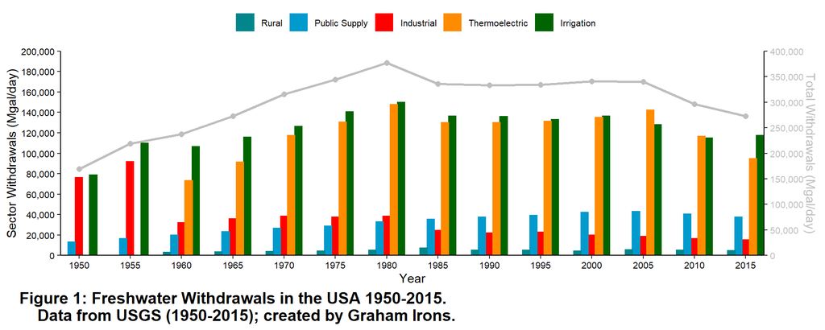

```r
ggplot() +
    geom_col(aes(x = Year,                                                      #bar graph
                 y = Withdrawals,
                 fill = reorder(Sector, Withdrawals)),
             data = wu_all_sector,
             position = position_dodge(3.5),
             width = 4)+
    scale_fill_manual(values = c(Rural = "turquoise4",                          #set bar colors and other aesthetics
                                "Public Supply" = "deepskyblue3",
                                Industrial = "red",
                                Thermoelectric = "darkorange",
                                Irrigation = "darkgreen")) +
    geom_line(aes(x = Year,                                                     #line plot
                  y = Withdrawals/2),
              data = wu_all_total,
              col = "grey",
              size = 1) +
    geom_point(aes(x = Year,                                                    #point plot
                   y = Withdrawals/2),
               data = wu_all_total,
               col = "grey",
               size = 2) +
    scale_x_continuous(breaks = scales::pretty_breaks(n = 14),                  #adds break lines to the background of the plot
                       expand = c(0, 0)) +                                      #brings bars all the way over to y-axis
    #trans function transforms the scale on the right side by multiple of 2
    scale_y_continuous(breaks = scales::pretty_breaks(n = 10),                  #adds break lines to the background of the plot
                       labels = scales::comma,
                       limits = c(0, 200000),
                       sec.axis = sec_axis(trans = ~.*2,
                                           breaks = scales::pretty_breaks(n = 10),
                                           name = "Total Withdrawals (Mgal/day)",
                                           labels = scales::comma),
                       expand = c(0, 0)) +                                      #brings bars all the way down to x-axis
    labs(caption = "Figure 1: Freshwater Withdrawals in the USA 1950-2015.
    Data from USGS (1950-2015); created by Graham Irons.",
         x = "Year",
         y = "Sector Withdrawals (Mgal/day)",
         fill = "") +
    theme_classic() +                                                           #removes background lines and color / simplifies
    theme(legend.position = "top",                                              #set theme options
          legend.text = element_text(color = "black", size = 8),
          axis.text = element_text(color = "black", size = 8),
          axis.title.y.right = element_text(color = "grey"),
          axis.text.y.right = element_text(color = "grey"),
          plot.caption = element_text(hjust = -0.15, size = 14, face = "bold"))
```

#**Q1: What is the take home message specific to Figure 1 with respect to water use by sector over time?** Industrial water use has decreased over time. While thermoelectric and public supply have both increased. In recent years, total freshwater withdrawals have decreased slightly.

#**Q2: What is the most surprising outcome to you of Figure 1?** The most surprising outcome of Figure 1 is freshwater withdrawals for the thermoelectric sector decreasing because this shows the U.S. is using more renewable energy.

#**Q3: Go to the USGS plot that shows withdrawals by sector (scroll down, the relevant plot is at the bottom); the bars in the USGS plot show different patterns than our plot. How is the plot different and why?** USGS includes thermoelectric and rural sectors for 1950-55. Their bars for thermoelectric are greater than ours. One explanation is that they might have combined the data from another sector with this one.